# dfyllinglab2

```python
import numpy as np
import matplotlib.pyplot as plt
from mpl_toolkits.mplot3d import axes3d
from pdffuns import *
```

## Lab 2

Daniel Fylling

### Problem 1

a) Stored values for my and Sgm in arrays for easier iteration. Reused norm2D from first lab for calculating grid points.

2D solution

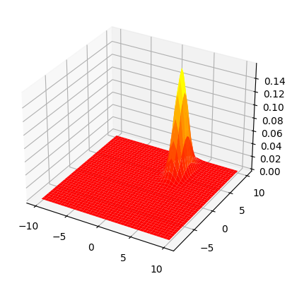

```python
x1 = np.arange(-10,10.5,0.5).reshape(-1,1)
x2 = np.arange(-9,10.5,0.5).reshape(-1,1)

my = []
Sgm = []
P = []

my.append(np.array([3,6]))
Sgm.append(np.array([[0.5,0],[0,2]]))
my.append(np.array([3,-2]))
Sgm.append(np.array([[2,0],[0,2]]))

for i in range(len(my)):
    p, x1v, x2v = norm2D(my[i], Sgm[i], x1, x2)
    P.append(p)

fig = plt.figure()
ax = fig.add_subplot(projection='3d')
ax.plot_surface(x1v, x2v, P[0], cmap='autumn')
```

b) As was mentioned in Lab description in Canvas, the 3D plotting doesnt work well while plotting different z-values for each x1, x2 grid point.

Using boolean masking to set the lowest value of Pw1 and Pw2 to Nan for each grid point.

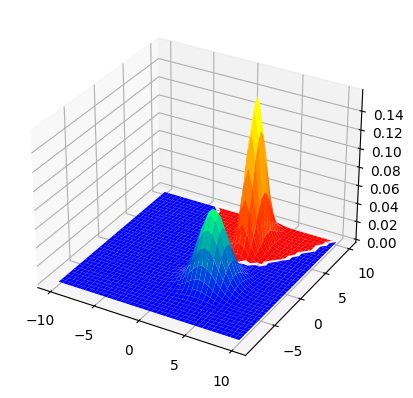

```python
a = P[0]
b = P[1]
mask = b<a
w1 = a.copy()*np.nan
w2 = a.copy()*np.nan

w1[mask] = a[mask]
w2[~mask] = b[~mask]

fig = plt.figure()
ax = fig.add_subplot(projection='3d')
ax.plot_surface(x1v, x2v, w1, cmap='autumn')
ax.plot_surface(x1v, x2v, w2, cmap='winter')
```

c)  
From here on I became a bit lazy and put in the prior probabilities manually to each plot. Ideally I would like to store these in arrays and iterate to make the functions reusable, but I will not prioritize time for that right now.

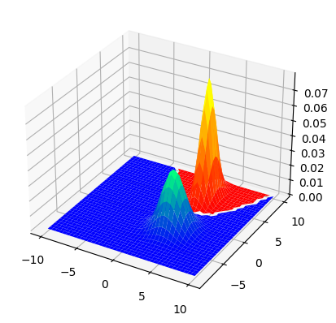

```python
fig = plt.figure()
ax = fig.add_subplot(projection='3d')
ax.plot_surface(x1v, x2v, w1*0.5, cmap='autumn')
ax.plot_surface(x1v, x2v, w2*0.5, cmap='winter')
```

d)  
The decision boundary can be seen as the white line between the coloured graphs. We can see that the decision boundary has a non-linear form of ax^2 + bx + c. The decision regions for w1 and w2 will be the red and blue areas, respectively.

e)  
Again, manually changed priors to adjust graphs.

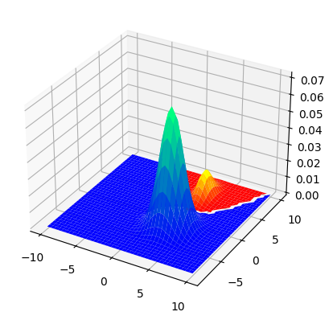

```python
fig = plt.figure()
ax = fig.add_subplot(projection='3d')
ax.plot_surface(x1v, x2v, w1*0.1, cmap='autumn')
ax.plot_surface(x1v, x2v, w2*0.9, cmap='winter')
```

f)  
Computing P(wi|x) from Bayes fomula and plotting. Again this could be done more clever with some iterations, but I'm leaving that for another day.

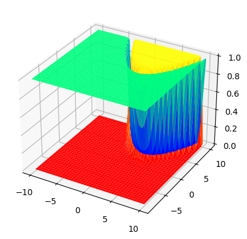

```python
Pw1x = P[0] * 0.5 / (P[0] * 0.5 + P[1] * 0.5)
Pw2x = P[1] * 0.5 / (P[0] * 0.5 + P[1] * 0.5)

fig = plt.figure()
ax = fig.add_subplot(projection='3d')
ax.plot_surface(x1v, x2v, Pw1x, cmap='autumn')
ax.plot_surface(x1v, x2v, Pw2x, cmap='winter')
```

[figure not shown]

```python
w1 = P[0] * 0.1 / (P[0] * 0.1 + P[1] * 0.9)
w2 = P[1] * 0.9 / (P[0] * 0.1 + P[1] * 0.9)

fig = plt.figure()
ax = fig.add_subplot(projection='3d')
ax.plot_surface(x1v, x2v, a, cmap='autumn')
ax.plot_surface(x1v, x2v, b, cmap='winter')
```

[figure not shown]

```python
# Here I tried to do some even more clever
# boolean masking for eliminating lower values in the plots.
# Could not get this quite to work for now.

# G=np.asarray(P)

# G[np.where(G==np.max(G, axis=0))] = np.nan

# fig = plt.figure()
# ax = fig.add_subplot(projection='3d')
# ax.plot_surface(x1v, x2v, G[0], cmap='autumn')
# ax.plot_surface(x1v, x2v, G[1], cmap='winter')
```